# Community ecology - Computer lab II - AB332

Anders K. Krabberød (UiO) and Ramiro Logares (ICM)

October 2023

# Computer lab II

First load the necessary packages.

Now load the the data from the previous lab (change path to the file if necessary):

```r
load("AB332_lab_I.RData")
```

# Distance metrics

Let’s calculate the Bray Curtis dissimilarities for the rarefied dataset

```r
otu.tab.trans.ss.nozero.bray <- vegdist(otu.tab.trans.ss.nozero, method = "bray")
as.matrix(otu.tab.trans.ss.nozero.bray)[1:5, 1:5]
```

```
##            Isa_120223 Isa_120301 Isa_120308 Isa_120320 Isa_120321
## Isa_120223  0.0000000  0.3085381  0.2645561  0.2919342  0.3010848
## Isa_120301  0.3085381  0.0000000  0.2531916  0.2057413  0.2080289
## Isa_120308  0.2645561  0.2531916  0.0000000  0.2609402  0.2899417
## Isa_120320  0.2919342  0.2057413  0.2609402  0.0000000  0.1354144
## Isa_120321  0.3010848  0.2080289  0.2899417  0.1354144  0.0000000
```

- *What kind of data is the Bray-Curtis dissimilarity suitable for?*
- *How can you change the dissimilarity index in the previous chunk of code?*

# Ordination and clustering

## PCA

Pca from the rarefied table

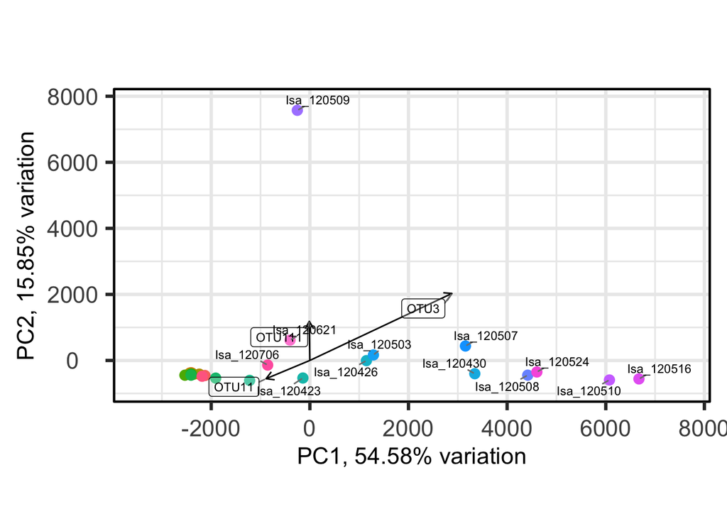

```r
otu.tab.trans.ss.nozero.pca <- PCAtools::pca(t(otu.tab.trans.ss.nozero), scale = FALSE) # Runs de PCA
biplot(otu.tab.trans.ss.nozero.pca, showLoadings = T, lab = rownames(otu.tab.trans.ss.nozero)) # Plots de PCA
```

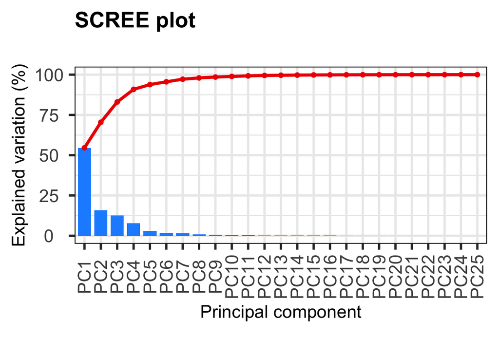

```r
screeplot(otu.tab.trans.ss.nozero.pca, axisLabSize = 18, titleLabSize = 22) # We plot the percentage of variance explained by each axis
```

## NMDS

```r
set.seed(666) # Set a seed to make results reproducible
NMDS.scree <- function(x) { # x is the name of the distance matrix
  plot(rep(1, 7), replicate(7, metaMDS(x, autotransform = FALSE, k = 1)$stress), xlim = c(1, 7), ylim = c(0, 0.30), xlab = "# of Dimensions", ylab = "Stress", main = "NMDS stress plot")
  for (i in 1:7) {
    points(rep(i + 1, 7), replicate(7, metaMDS(x, autotransform = FALSE, k = i + 1)$stress))
  }
}
```

We calculate NMDS for k(dimensions)=2 Rarefied table (we use the dataframe to have access to sample and OTU names)

```r
otu.tab.trans.ss.nozero.bray.nmds <- metaMDS(otu.tab.trans.ss.nozero, k = 2, trymax = 100, trace = FALSE, autotransform = FALSE, distance = "bray")
otu.tab.trans.ss.nozero.bray.nmds
```

```
##
## Call:
## metaMDS(comm = otu.tab.trans.ss.nozero, distance = "bray", k = 2,      trymax = 100, autotransform = FALSE, trace = FALSE)
##
## global Multidimensional Scaling using monoMDS
##
## Data:     otu.tab.trans.ss.nozero
## Distance: bray
##
## Dimensions: 2
## Stress:     0.06354218
## Stress type 1, weak ties
## Best solution was repeated 1 time in 30 tries
## The best solution was from try 17 (random start)
## Scaling: centring, PC rotation, halfchange scaling
## Species: expanded scores based on 'otu.tab.trans.ss.nozero'
```

# Make stressplot

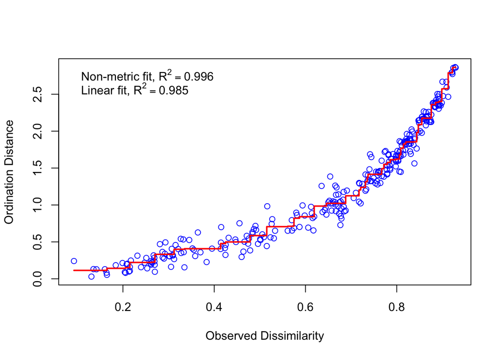

```r
stressplot(otu.tab.trans.ss.nozero.bray.nmds)
```

Simple plotting  
Rarefied table

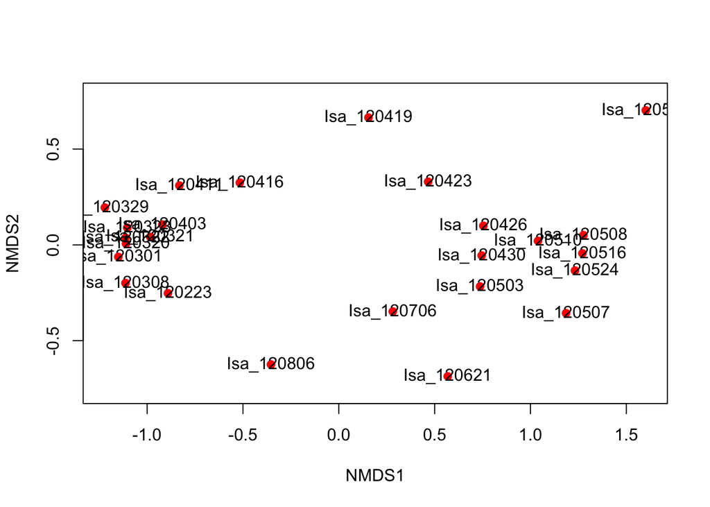

```r
plot(otu.tab.trans.ss.nozero.bray.nmds, display = "sites", type = "n")
points(otu.tab.trans.ss.nozero.bray.nmds, display = "sites", col = "red", pch = 19)
text(otu.tab.trans.ss.nozero.bray.nmds, display = "sites")
```

### Let’s make nicer plots

We get the seasons for samples

```r
isa.metadata <- read_tsv("https://raw.githubusercontent.com/krabberod/UNIS_AB332_2022/main/computer_lab/data/AB332metadata_v3.txt")
isa.metadata <- column_to_rownames(isa.metadata, var = "Sample_Name")
isa.metadata.simp <- isa.metadata[6:30, ]
```

Rarefied table We generate a table of nmds scores and other features

```r
otu.tab.trans.ss.nozero.bray.nmds.scores <- as.data.frame(scores(otu.tab.trans.ss.nozero.bray.nmds)$sites)
otu.tab.trans.ss.nozero.bray.nmds.scores$season <- isa.metadata.simp$seasons
otu.tab.trans.ss.nozero.bray.nmds.scores$month <- as.factor(isa.metadata.simp$month)
otu.tab.trans.ss.nozero.bray.nmds.scores$samples <- rownames(otu.tab.trans.ss.nozero.bray.nmds.scores)
```

Create the plot

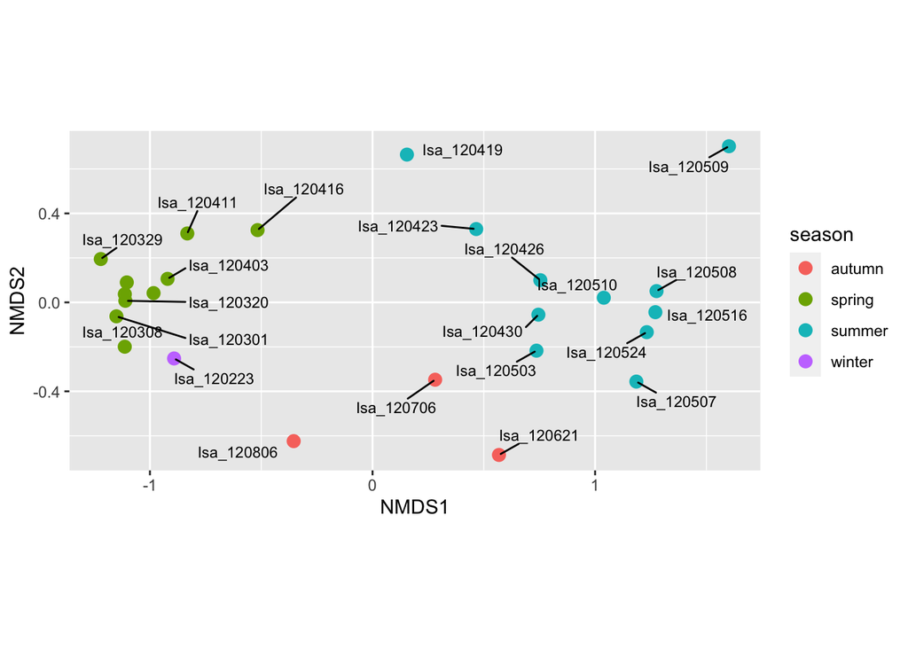

```r
ggplot(otu.tab.trans.ss.nozero.bray.nmds.scores) +
  geom_point(mapping = aes(x = NMDS1, y = NMDS2, colour = season), size = 3) +
  coord_fixed() + ## need aspect ratio of 1!
  geom_text_repel(
    box.padding = 0.5, aes(x = NMDS1, y = NMDS2, label = samples),
    size = 3
  )
```

#Clustering of samples

Allows determining the similarity between samples as well as the organization of samples in groups. Hierarchical clustering: samples will be organized in ranks according to their similarity and all samples will be included in a large group Unweighted Pair-Group Method Using Arithmetic Averages (UPGMA): This linkage method will link samples by considering their distance to a subgroup arithmetic average. This is a method widely used in ecology

### UPGMA

Rarefied dataset We generate 100 trees by re-sampling and then, we plot the consensus tree

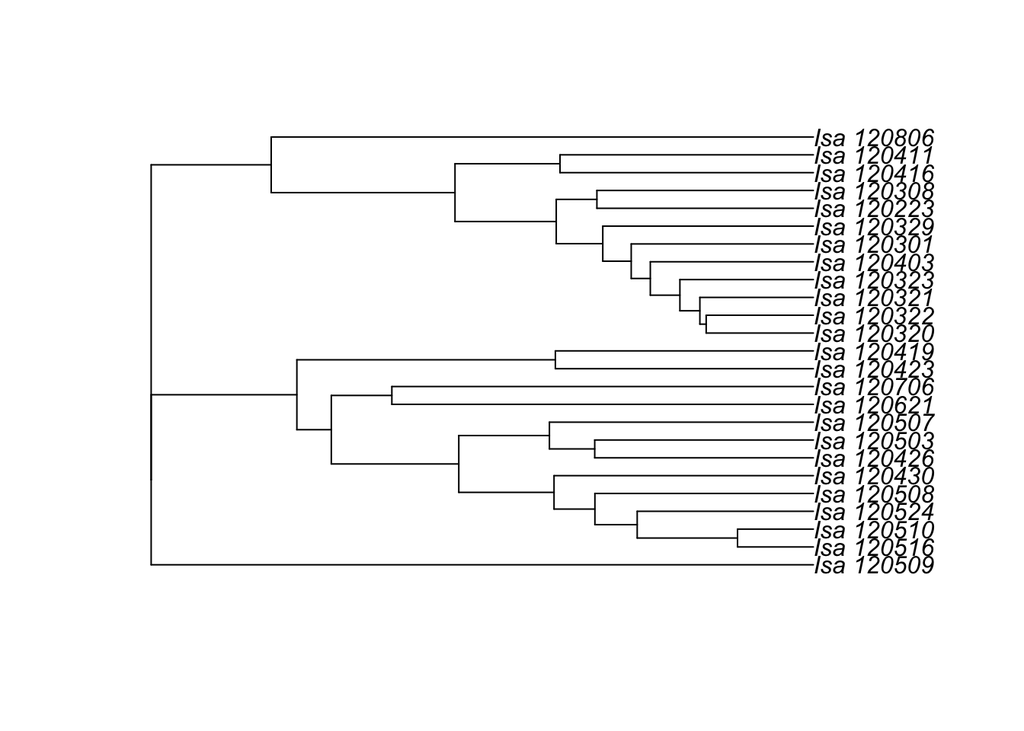

```r
otu.tab.trans.ss.nozero.bray.upgma <- recluster.cons(otu.tab.trans.ss.nozero.bray, tr = 100, p = 0.5, method = "average")
plot(otu.tab.trans.ss.nozero.bray.upgma$cons) # plot consensus tree
```

We’ll calculate bootstrap support values (0: bad - 100: perfect) This allows us to know how well supported is the branching pattern The oostrapping function may take a while to run (depending on your computer)

[figure not shown]

```r
otu.tab.trans.ss.nozero.bray.upgma.boot <- recluster.boot(otu.tab.trans.ss.nozero.bray.upgma$cons, otu.tab.trans.ss.nozero, tr = 100, p = 0.5, method = "average", boot = 1000, level = 1)
recluster.plot(otu.tab.trans.ss.nozero.bray.upgma$cons, otu.tab.trans.ss.nozero.bray.upgma.boot, direction="right") # We add bootstrap values to the branching pattern
```

```r
save.image("AB332_lab_II.RData")
```